# Assignment pml predict

P Sohan

10/20/2020

## Brief Backgd

We are Performing this project to predict the way with which participants perform a barbell lift. Now a days we have the technology like Fitbit, Nike fuelband to collect data about a persons activities. The data used here is from: http://groupware.les.inf.puc-rio.br/har

## Intials

We use various training and test sets from the sources online.

```r
library(caret)
```

```r
#usingcaret
setwd("C:/Users/MAHE/Documents")
#setingpath
#gtnurls
exeURL <- "http://d396qusza40orc.cloudfront.net/predmachlearn/pml-training.csv"
#gtnurlss
exetURL <- "http://d396qusza40orc.cloudfront.net/predmachlearn/pml-testing.csv"
#trngtransfer
trining <- read.csv(url(exeURL))
#tstng_trnfr
tstingg <- read.csv(url(exetURL))
label<- createDataPartition(trining$classe, p = 0.7, list = FALSE)
trinbb <- trining[label, ]
tstbbb <- trining[-label, ]
```

There are a lot of variables in the data set so we try to reduce them with the help of the below given chunk. Alot of these variables are not needed so we just get rid of them. The main goal of this stage is to reduce the data set by gettinig rid of some unwanted datas.

```r
NnZro <- nearZeroVar(trinbb)
#varzero
trinbb <- trinbb[ ,-NnZro]
#trnngset
tstbbb <- tstbbb[ ,-NnZro]
#label_usntr
label<- apply(trinbb, 2, function(x) mean(is.na(x))) > 0.95
#bhbhb
trinbb <- trinbb[, -which(label, label== FALSE)]
tstbbb <- tstbbb[, -which(label, label == FALSE)]
trinbb <- trinbb[ , -(1:5)]
tstbbb <- tstbbb[ , -(1:5)]
```

## plotinggph

We have removed uncessary variabls. Now we will see how the vsr depend on each other. For that matter we create plot and observe.We use the corrplot library. We then create a relationship plot among the variables.

```r
library(corrplot)
```

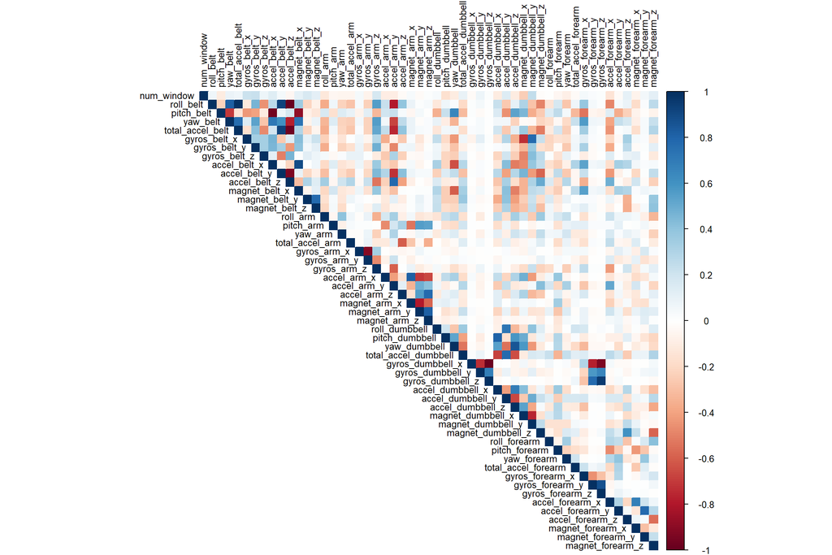

```r
#lib_remember
corrMat <- cor(trinbb[,-54])
#placing_it
corrplot(corrMat, method = "color", type = "upper", tl.cex = 0.8, tl.col = rgb(0,0,0))
```

Dark regions have high relnsp tg[ns]

## first modell Dcsntree

### Dsdnt

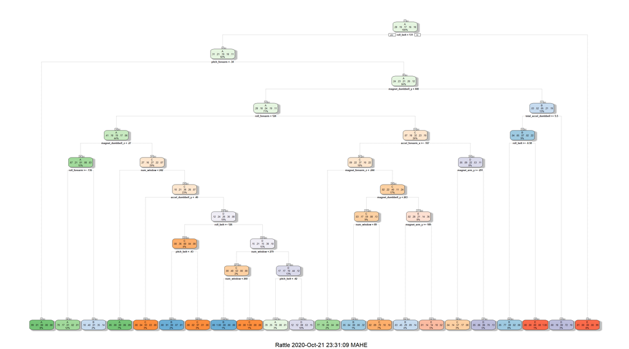

```r
library(rpart)
library(rpart.plot)
library(rattle)
#libs
set.seed(13908)
#sdng
modelldD <- rpart(classe ~ ., data = trinbb, method = "class")
#modelled
fancyRpartPlot(modelldD)
```

```r
#usgn_fn
predicttdD <- predict(modelldD, tstbbb, type = "class")
#prdtng
confMattrrrD <- confusionMatrix(predicttdD, tstbbb$classe)
confMattrrrD
```

```
## Confusion Matrix and Statistics
##
##           Reference
## Prediction    A    B    C    D    E
##          A 1494  211   39   67   59
##          B   45  698   98   82  110
##          C   20   67  798   84   48
##          D  108  128   61  666  142
##          E    7   35   30   65  723
##
## Overall Statistics
##
##                Accuracy : 0.7441
##                  95% CI : (0.7327, 0.7552)
##     No Information Rate : 0.2845
##     P-Value [Acc > NIR] : < 2.2e-16
##
##                   Kappa : 0.6752
##
##  Mcnemar's Test P-Value : < 2.2e-16
##
## Statistics by Class:
##
##                      Class: A Class: B Class: C Class: D Class: E
## Sensitivity            0.8925   0.6128   0.7778   0.6909   0.6682
## Specificity            0.9107   0.9294   0.9549   0.9108   0.9715
## Pos Pred Value         0.7989   0.6757   0.7847   0.6027   0.8407
## Neg Pred Value         0.9552   0.9091   0.9532   0.9377   0.9286
## Prevalence             0.2845   0.1935   0.1743   0.1638   0.1839
## Detection Rate         0.2539   0.1186   0.1356   0.1132   0.1229
## Detection Prevalence   0.3178   0.1755   0.1728   0.1878   0.1461
## Balanced Accuracy      0.9016   0.7711   0.8664   0.8008   0.8198
```

### secong modell of randFrt

```r
#we are going to try using randomforest
library(caret)
#libs
set.seed(13908)
#putng_ctrl
control <- trainControl(method = "cv", number = 3, verboseIter=FALSE)
#putng_modelled
modellrrR <- train(classe ~ ., data = trinbb, method = "rf", trControl = control)
modellrrR$finalModel
```

```
##
## Call:
##  randomForest(x = x, y = y, mtry = param$mtry)
##                Type of random forest: classification
##                      Number of trees: 500
## No. of variables tried at each split: 27
##
##         OOB estimate of  error rate: 0.2%
## Confusion matrix:
##      A    B    C    D    E  class.error
## A 3905    0    0    0    1 0.0002560164
## B    9 2648    1    0    0 0.0037622272
## C    0    4 2392    0    0 0.0016694491
## D    0    0    8 2243    1 0.0039964476
## E    0    1    0    3 2521 0.0015841584
```

```r
#prdictd_val
predictteddR <- predict(modellrrR, tstbbb)
confMatrRrrf <- confusionMatrix(predictteddR, tstbbb$classe)
confMatrRrrf
```

```
## Confusion Matrix and Statistics
##
##           Reference
## Prediction    A    B    C    D    E
##          A 1674    1    0    0    0
##          B    0 1135    1    0    0
##          C    0    2 1025    7    0
##          D    0    1    0  957    1
##          E    0    0    0    0 1081
##
## Overall Statistics
##
##                Accuracy : 0.9978
##                  95% CI : (0.9962, 0.9988)
##     No Information Rate : 0.2845
##     P-Value [Acc > NIR] : < 2.2e-16
##
##                   Kappa : 0.9972
##
##  Mcnemar's Test P-Value : NA
##
## Statistics by Class:
##
##                      Class: A Class: B Class: C Class: D Class: E
## Sensitivity            1.0000   0.9965   0.9990   0.9927   0.9991
## Specificity            0.9998   0.9998   0.9981   0.9996   1.0000
## Pos Pred Value         0.9994   0.9991   0.9913   0.9979   1.0000
## Neg Pred Value         1.0000   0.9992   0.9998   0.9986   0.9998
## Prevalence             0.2845   0.1935   0.1743   0.1638   0.1839
## Detection Rate         0.2845   0.1929   0.1742   0.1626   0.1837
## Detection Prevalence   0.2846   0.1930   0.1757   0.1630   0.1837
## Balanced Accuracy      0.9999   0.9981   0.9986   0.9962   0.9995
```

### third modell of gbm

```r
#trying gbm method
library(caret)
#libcaret
set.seed(13908)
#cntrl_put
control <- trainControl(method = "repeatedcv", number = 5, repeats = 1, verboseIter = FALSE)
#modelled
modelGBbbm <- train(classe ~ ., data = trinbb, trControl = control, method = "gbm", verbose = FALSE)
modelGBbbm$finalModel
```

```
## A gradient boosted model with multinomial loss function.
## 150 iterations were performed.
## There were 53 predictors of which 53 had non-zero influence.
```

```r
#prditd_usgn
predictGBbbm <- predict(modelGBbbm, tstbbb)
confMatrGBbbm <- confusionMatrix(predictGBbbm, tstbbb$classe)
confMatrGBbbm
```

```
## Confusion Matrix and Statistics
##
##           Reference
## Prediction    A    B    C    D    E
##          A 1674   11    0    0    0
##          B    0 1118    8    1    6
##          C    0   10 1012   11    2
##          D    0    0    5  951   10
##          E    0    0    1    1 1064
##
## Overall Statistics
##
##                Accuracy : 0.9888
##                  95% CI : (0.9858, 0.9913)
##     No Information Rate : 0.2845
##     P-Value [Acc > NIR] : < 2.2e-16
##
##                   Kappa : 0.9858
##
##  Mcnemar's Test P-Value : NA
##
## Statistics by Class:
##
##                      Class: A Class: B Class: C Class: D Class: E
## Sensitivity            1.0000   0.9816   0.9864   0.9865   0.9834
## Specificity            0.9974   0.9968   0.9953   0.9970   0.9996
## Pos Pred Value         0.9935   0.9868   0.9778   0.9845   0.9981
## Neg Pred Value         1.0000   0.9956   0.9971   0.9974   0.9963
## Prevalence             0.2845   0.1935   0.1743   0.1638   0.1839
## Detection Rate         0.2845   0.1900   0.1720   0.1616   0.1808
## Detection Prevalence   0.2863   0.1925   0.1759   0.1641   0.1811
## Balanced Accuracy      0.9987   0.9892   0.9908   0.9917   0.9915
```

the most accurate result is obtained from Random forest method. So we will use this method to get results for the tests.

## Getting Results

```r
#finding out prediction for the set
predictteddR <- predict(modellrrR, tstingg)
predictteddR
```

```
##  [1] B A B A A E D B A A B C B A E E A B B B
## Levels: A B C D E
```